# A Classification problem solution attempt with Decision Tree Classifiers, Random Forest Classifiers, Artificial Neural Networks, Gradient Boosting Classifier, K-Neighbors Classifier & Logistic Regress

# Comparing all models

## Comparison of accuracy of the split test data-validation data

```python
#Organizando todos los scores que habia obtenido antes
scores=[]
classific=["Logistic Regression","Decisition tree","Random Forest","Artifitial Neural Network","Gradient Boost Classifier","K-Near Neighbors"]
for i in range(0,12,2):
  scores.append([classific[int(i/2)],eval('ac'+str(i)),eval('ac'+str(i+1)),eval('ac'+str(i+1)+'b')])
title=["Classificator","Accuracy w/n parameters","Accuracy w parameters GSV","Accuracy w parameters RSV"]

print(tabulate(scores, headers=title,numalign="left",floatfmt="1.3e",tablefmt="github"))
```

```
| Classificator             | Accuracy w/n parameters   | Accuracy w parameters GSV   | Accuracy w parameters RSV   |
|---------------------------|---------------------------|-----------------------------|-----------------------------|
| Logistic Regression       | 7.912e-01                 | 7.912e-01                   | 7.912e-01                   |
| Decisition tree           | 8.143e-01                 | 8.515e-01                   | 8.511e-01                   |
| Random Forest             | 8.858e-01                 | 8.858e-01                   | 8.843e-01                   |
| Artifitial Neural Network | 8.744e-01                 | 8.749e-01                   | 8.715e-01                   |
| Gradient Boost Classifier | 8.719e-01                 | 8.797e-01                   | 8.793e-01                   |
| K-Near Neighbors          | 8.318e-01                 | 8.402e-01                   | 8.372e-01                   |
```

| Classificator | Accuracy w/n parameters | Accuracy w parameters GSV | Accuracy w parameters RSV |
| --- | --- | --- | --- |
| Logistic Regression | 7.912e-01 | 7.912e-01 | 7.912e-01 |
| Decisition tree | 8.143e-01 | 8.515e-01 | 8.511e-01 |
| Random Forest | 8.858e-01 | 8.858e-01 | 8.843e-01 |
| Artifitial Neural Network | 8.744e-01 | 8.749e-01 | 8.715e-01 |
| Gradient Boost Classifier | 8.719e-01 | 8.797e-01 | 8.793e-01 |
| K-Near Neighbors | 8.318e-01 | 8.402e-01 | 8.372e-01 |

The best Classifier, in terms of accuracy, for this division of test-validation is the Random Forest. There is not noticeable improvement when tunned parameters are used.

## Comparison of AUC done with the split test data-validation data

```python
#Organizando todos los scores que habia obtenido antes
scores=[]

for i in range(0,12,2):
  scores.append([classific[int(i/2)],eval('r'+str(i)),eval('r'+str(i+1)),eval('r'+str(i+1)+'b')])
title=["Classificator","AUC w/n parameters","AUC w parameters GSV","AUC w parameters RSV"]

print(tabulate(scores, headers=title,numalign="left",floatfmt="1.3e",tablefmt="github"))
```

```
| Classificator             | AUC w/n parameters   | AUC w parameters GSV   | AUC w parameters RSV   |
|---------------------------|----------------------|------------------------|------------------------|
| Logistic Regression       | 8.412e-01            | 8.412e-01              | 8.412e-01              |
| Decisition tree           | 8.269e-01            | 9.012e-01              | 9.003e-01              |
| Random Forest             | 8.323e-01            | 9.363e-01              | 9.360e-01              |
| Artifitial Neural Network | 9.312e-01            | 9.294e-01              | 9.273e-01              |
| Gradient Boost Classifier | 9.239e-01            | 9.260e-01              | 9.243e-01              |
| K-Near Neighbors          | 8.705e-01            | 8.923e-01              | 8.974e-01              |
```

| Classificator | AUC w/n parameters | AUC w parameters GSV | AUC w parameters RSV |
| --- | --- | --- | --- |
| Logistic Regression | 8.412e-01 | 8.412e-01 | 8.412e-01 |
| Decisition tree | 8.269e-01 | 9.012e-01 | 9.003e-01 |
| Random Forest | 8.323e-01 | 9.363e-01 | 9.360e-01 |
| Artifitial Neural Network | 9.312e-01 | 9.294e-01 | 9.273e-01 |
| Gradient Boost Classifier | 9.239e-01 | 9.260e-01 | 9.243e-01 |
| K-Near Neighbors | 8.705e-01 | 8.923e-01 | 8.974e-01 |

The best Classifier, in terms of AUC, for this division of test-validation is the Random Forest. There is a noticeable improvement when tunned parameters are used, specially whith GridSearchCV.

## Comparison of mean accuracy with Cross Validation (5 sets)

```python
#Organizando todos los scores que habia obtenido antes
scores=[]

for i in range(0,12,2):
  scores.append([classific[int(i/2)],np.mean(eval('score'+str(i))),np.mean(eval('score'+str(i+1))),np.mean(eval('score'+str(i+1)+'b'))])
title=["Classificator","Accuracy w/n parameters","Accuracy w parameters GSV","Accuracy w parameters RSV"]

print(tabulate(scores, headers=title,numalign="left",floatfmt="1.3e",tablefmt="github"))
```

```
| Classificator             | Accuracy w/n parameters   | Accuracy w parameters GSV   | Accuracy w parameters RSV   |
|---------------------------|---------------------------|-----------------------------|-----------------------------|
| Logistic Regression       | 7.908e-01                 | 7.906e-01                   | 7.906e-01                   |
| Decisition tree           | 8.181e-01                 | 8.501e-01                   | 8.498e-01                   |
| Random Forest             | 8.810e-01                 | 8.811e-01                   | 8.807e-01                   |
| Artifitial Neural Network | 8.302e-01                 | 8.179e-01                   | 8.262e-01                   |
| Gradient Boost Classifier | 8.710e-01                 | 8.716e-01                   | 8.758e-01                   |
| K-Near Neighbors          | 8.382e-01                 | 8.425e-01                   | 8.385e-01                   |
```

| Classificator | Accuracy w/n parameters | Accuracy w parameters GSV | Accuracy w parameters RSV |
| --- | --- | --- | --- |
| Logistic Regression | 7.908e-01 | 7.906e-01 | 7.906e-01 |
| Decisition tree | 8.181e-01 | 8.501e-01 | 8.498e-01 |
| Random Forest | 8.810e-01 | 8.811e-01 | 8.807e-01 |
| Artifitial Neural Network | 8.302e-01 | 8.179e-01 | 8.262e-01 |
| Gradient Boost Classifier | 8.710e-01 | 8.716e-01 | 8.758e-01 |
| K-Near Neighbors | 8.382e-01 | 8.425e-01 | 8.385e-01 |

The best classificator is the Random Forest. The accuracy is better when the hyperparameters are tunned, but between methods of tunning there is not difference.

## ROC curves

### ROC w/o Tunning Hyperparameters

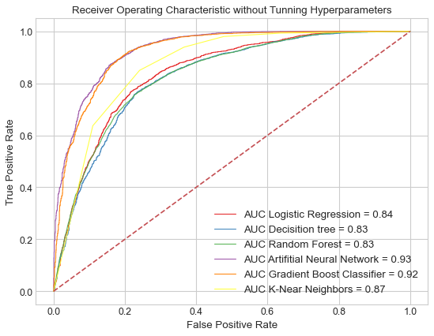

```python
# multiple plot
palette = plt.get_cmap('Set1')#color library

figure(num=None, figsize=(8, 6), dpi=80, facecolor='w', edgecolor='k')

for i in range(0,12,2):
    plt.plot(eval('rx'+str(i)), eval('ry'+str(i)), marker='', color=palette(int(i/2)),
             linewidth=1, alpha=0.9, label='AUC '+classific[int(i/2)]+' = %0.2f' %eval('r'+str(i)))

# Add titles
plt.plot([0, 1], [0, 1],'r--')
plt.title('Receiver Operating Characteristic '+'without Tunning Hyperparameters',fontsize=12)
plt.ylabel('True Positive Rate',fontsize=12)
plt.xlabel('False Positive Rate',fontsize=12)

# Add legend
plt.legend(loc = 'lower right', prop={'size': 12})
plt.show()
```

### ROC w Tunned Hyperparameters GSCV

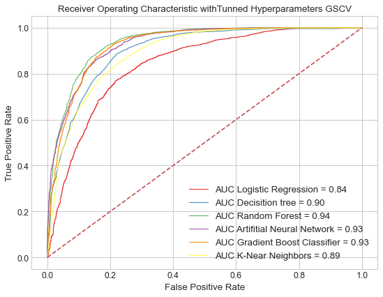

```python
# multiple plot
figure(num=None, figsize=(8, 6), dpi=80, facecolor='w', edgecolor='k')

for i in range(0,12,2):
    plt.plot(eval('rx'+str(i+1)), eval('ry'+str(i+1)), marker='', color=palette(int(i/2)),
             linewidth=1, alpha=0.9, label='AUC '+classific[int(i/2)]+' = %0.2f' %eval('r'+str(i+1)))

# Add titles
plt.plot([0, 1], [0, 1],'r--')
plt.title('Receiver Operating Characteristic '+'withTunned Hyperparameters GSCV',fontsize=12)
plt.ylabel('True Positive Rate',fontsize=12)
plt.xlabel('False Positive Rate',fontsize=12)

# Add legend
plt.legend(loc = 'lower right', prop={'size': 12})
plt.show()
```

### ROC w Tunned Hyperparameters RSCV

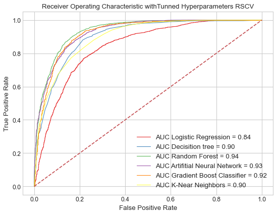

```python
# multiple plot
figure(num=None, figsize=(8, 6), dpi=80, facecolor='w', edgecolor='k')

for i in range(0,12,2):
    plt.plot(eval('rx'+str(i+1)+'b'), eval('ry'+str(i+1)+'b'), marker='', color=palette(int(i/2)),
             linewidth=1, alpha=0.9, label='AUC '+classific[int(i/2)]+' = %0.2f' %eval('r'+str(i+1)+'b'))

# Add titles
plt.plot([0, 1], [0, 1],'r--')
plt.title('Receiver Operating Characteristic '+'withTunned Hyperparameters RSCV',fontsize=12)
plt.ylabel('True Positive Rate',fontsize=12)
plt.xlabel('False Positive Rate',fontsize=12)

# Add legend
plt.legend(loc = 'lower right', prop={'size': 12})
plt.show()
```

# Cutting: signal and background

Later, the significance function is again defined. It is defined here to obtain the significance of the data after passing the slicing by minimization function -[2(n signal)-(n background)]

```python
datasets = {}
by_class = df.groupby('class')
#dividing the datased by background and signal
for groups, data in by_class:
    datasets[groups] = data.drop(columns=['class'])
signn=len(datasets['g'])#number of events that are signal
backn=len(datasets['h'])#number of events which are background
```

```python
def significance(x,i):
    #señal
    j = datasets['g'].iloc[:,i].values
    gg=len([1 for o in j if x[0] < o < x[1] ])#number of signal events between cuts
    if gg==0:
      gg=2.220446049250313e-16# this is the minimum number support by 32 bits. its to avoid 0's in the denominator
    #fondo
    j = datasets['h'].iloc[:,i].values
    hh=len([1 for o in j if x[0] < o < x[1]]) #number of background events between cuts
    return gg/(hh**0.5)
```

## Signal and background - parameter distributions (without cuts):

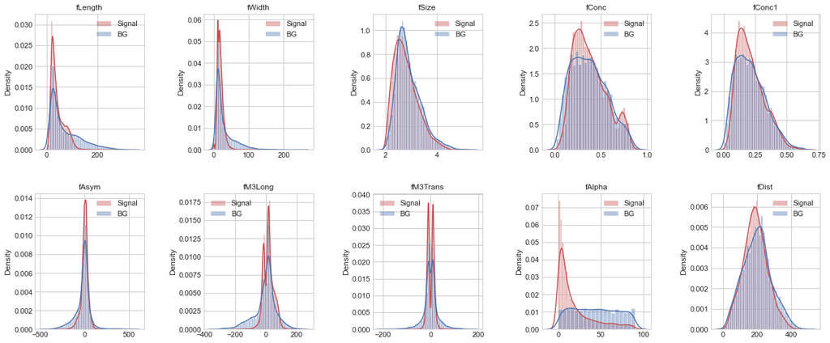

```python
fig, ax = plt.subplots(2,5, figsize=(18, 8))
ax = ax.flatten()
for i in range(10):
    sns.distplot(datasets['g'].iloc[:,i].values, ax=ax[i],color='r', label='Signal',norm_hist=True)
    sns.distplot(datasets['h'].iloc[:,i].values, ax=ax[i],color='b', label='BG',norm_hist=True)
    ax[i].set_title(datasets['g'].columns[i])
    ax[i].legend(loc="best")
fig.tight_layout(pad=2.0)
```

## Minimization function: -[2*(#signal)-(#background)]

Obtaining the cuts from the minimization (optimization) of the function -[2*(#signal)-(#background)]

```python
#mnimization function
def cut0(x,i):
    j = datasets['g'].iloc[:,i].values#signal data
    gg=len([1 for o in j if x[0] < o < x[1] ])#number of signal events
    j = datasets['h'].iloc[:,i].values#background data
    hh=len([1 for o in j if x[0] < o < x[1]]) #number of background events
    return -1*(gg*2-hh)#minimization function
```

### CG method of minimization

```python
cortes0=[]#to save the cut values
significan0=[]#to save the significance final value
for i in range(10):
    x0 = np.array([min(datasets['g'].iloc[:,i].values), max(datasets['g'].iloc[:,i].values)])#the initial limits are the extremal values of the signal data
    print(str(df.columns[i]))
    res0 = minimize(cut0, x0,args=(i), method='CG',#'type of solver',
                  options={'disp': True})#'xatol': 1e-8,...,bounds=(min(datasets['g'].iloc[:,i].values), max(datasets['h'].iloc[:,i].values)))
    limits=res0.x#the limits returned by the minimizer are save in this variable
    significan0.append(significance(limits,i))#we evluate the cut values to obtain the significance
    print(limits)
    cortes0.append(limits)
    print()
```

```
fLength
Optimization terminated successfully.
         Current function value: -18057.000000
         Iterations: 1
         Function evaluations: 33
         Gradient evaluations: 11
[ 12.1929     272.06305126]

fWidth
Optimization terminated successfully.
         Current function value: -17850.000000
         Iterations: 1
         Function evaluations: 33
         Gradient evaluations: 11
[  0.         176.33505126]

fSize
Optimization terminated successfully.
         Current function value: -17981.000000
         Iterations: 1
         Function evaluations: 33
         Gradient evaluations: 11
[1.9978     5.01005127]

fConc
Optimization terminated successfully.
         Current function value: -17980.000000
         Iterations: 1
         Function evaluations: 33
         Gradient evaluations: 11
[0.0139     0.88895126]

fConc1
Optimization terminated successfully.
         Current function value: -17982.000000
         Iterations: 1
         Function evaluations: 33
         Gradient evaluations: 11
[0.0073     0.67525126]

```

[output cut: 24 more lines]

```
fAlpha
Optimization terminated successfully.
         Current function value: -17966.000000
         Iterations: 1
         Function evaluations: 33
         Gradient evaluations: 11
[ 0.         90.00005126]

fDist
Optimization terminated successfully.
         Current function value: -17981.000000
         Iterations: 1
         Function evaluations: 33
         Gradient evaluations: 11
[  5.7456     450.40205126]
```

#### Combination of all cuts

Cutting the dataset:

```python
dfcutall0=df
sizw=[len(dfcutall0)]#para ver como disminuye el tamaño de la data
for i in range(10):
  Xcut=cortes0[i]#asignas lista [corte izq,corte der]
  name=dfcutall0.columns[i]#nombre del parametro
  dfcutall0=dfcutall0[(dfcutall0[name] >Xcut[0]) & (dfcutall0[name] <Xcut[1])].dropna()#aqui se hace el corte
  sizw.append(len(dfcutall0))#guardas el tamaño del dataset tras el corte
```

Once the data is cutted, lets split the data in signal v background:

```python
datasetcutall = {}
by_class = dfcutall0.groupby('class')

for groups, data in by_class:
    datasetcutall[groups] = data.drop(columns=['class'])

#number of events that are signal:
signcutall0=len(datasetcutall['g'])
# number of events that are background:
backcutall0=len(datasetcutall['h'])
```

Dividing the data in X and y:

```python
# Create target object and call it y
ycutall0 = dfcutall0['class'].replace('g',1).replace('h',0)

# Create X
features = list(dfcutall0)[:-1]
Xcutall0 = dfcutall0[features]
```

Plots of distributions

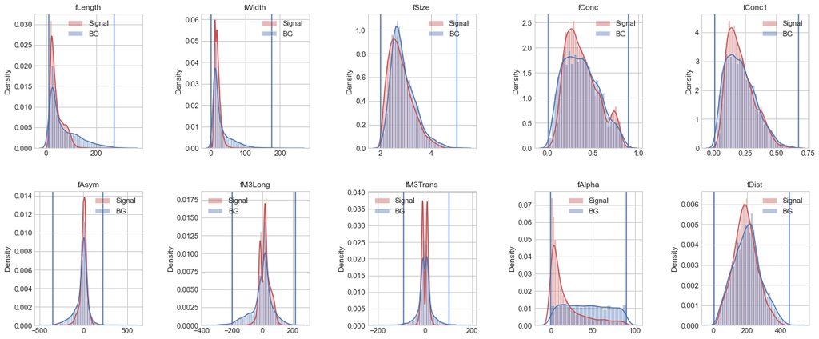

```python
fig, ax = plt.subplots(2,5, figsize=(18, 8))
ax = ax.flatten()
for i in range(10):
    sns.distplot(datasets['g'].iloc[:,i].values, ax=ax[i],color='r', label='Signal')
    sns.distplot(datasets['h'].iloc[:,i].values, ax=ax[i],color='b', label='BG')
    cor=cortes0[i]
    ax[i].axvline( x=cor[0], ymin=0, ymax=1)
    ax[i].axvline( x=cor[1], ymin=0, ymax=1)
    ax[i].set_title(datasets['g'].columns[i])
    ax[i].legend(loc="best")
fig.tight_layout(pad=2.0)
```

Cross validation with the best classifier

```python
#random Forest with the best parameters obtained with GSCV
rf_model_c0  = RandomForestClassifier(criterion='entropy',random_state = 0,
                                bootstrap=RFC_params["bootstrap"],
                                max_depth=RFC_params["max_depth"],
                                max_features=RFC_params["max_features"],
                                n_estimators=RFC_params["n_estimators"],
                                );
scores0=[]#to save the cross validations score
porcsignal0=[]#to save the fraction of signal events after the cut in comparison of the initial signal events
porbackground0=[]#to save the fraction of background events after the cut in comparison of the initial background events
portot0=[]#to save the fraction of all events after the cut in comparison of all initial events
#Score of the Random Forest Classifier model :
for i in range(10):#for each parameter of the data
    datasetc0 = {}
    Xcut0=cortes0[i]
    name=df.columns[i]
    dfcut0=df[(df[name] >Xcut0[0]) & (df[name] <Xcut0[1])].dropna()#cutting the data
    #splitting the data between background and signal
    by_classc0 = dfcut0.groupby('class')

    for groups, data in by_classc0:
          datasetc0[groups] = data.drop(columns=['class'])

    #saving the fractions
    porcsignal0.append(len(datasetc0['g'])/signn)
    porbackground0.append(len(datasetc0['h'])/backn)
    portot0.append(len(dfcut0)/len(df))

    # Create target object and call it y
    ycut0 = dfcut0['class'].replace('g',1).replace('h',0)

    # Create X
    features0 = list(dfcut0)[:-1]
    Xcut0 = dfcut0[features0]
    score0=cross_val_score(rf_model_c0, Xcut0, ycut0, scoring='accuracy')
    scores0.append(score0)
    #print(name+' cut')
    #print(score2)
    #print()
```

Cross validation

```python
cutall0= cross_val_score(rf_model_c0, Xcutall0, ycutall0, scoring='accuracy')
```

Summary

```python
cut_0=[]
for i in range(10):
  cut_0.append([df.columns[i],porcsignal0[i],porbackground0[i],portot0[i],scores0[i].mean(),significan0[i],significan0[i]/(signn/backn**0.5)])

cut_0.append(["All",signcutall0/signn,backcutall0/backn,(backcutall0+signcutall0)/len(df),cutall0.mean(),(-1*backcutall0+2*signcutall0),(-1*backcutall0+2*signcutall0)/(2*signn-backn)])
title=["Parameter","Signal","Background","Total","Mean Accuracy RFC w GSCV estimators","Significance","Relative significance"]

print(tabulate(cut_0, headers=title,numalign="right",floatfmt="1.3e",tablefmt="github"))
```

```
| Parameter   |    Signal |   Background |     Total |   Mean Accuracy RFC w GSCV estimators |   Significance |   Relative significance |
|-------------|-----------|--------------|-----------|---------------------------------------|----------------|-------------------------|
| fLength     | 9.999e-01 |    9.876e-01 | 9.956e-01 |                             8.807e-01 |      1.517e+02 |               1.006e+00 |
| fWidth      | 9.937e-01 |    9.955e-01 | 9.943e-01 |                             8.823e-01 |      1.502e+02 |               9.959e-01 |
| fSize       | 9.999e-01 |    9.990e-01 | 9.996e-01 |                             8.811e-01 |      1.509e+02 |               1.000e+00 |
| fConc       | 9.999e-01 |    9.991e-01 | 9.996e-01 |                             8.812e-01 |      1.508e+02 |               1.000e+00 |
| fConc1      | 9.999e-01 |    9.988e-01 | 9.995e-01 |                             8.810e-01 |      1.509e+02 |               1.001e+00 |
| fAsym       | 9.999e-01 |    9.919e-01 | 9.971e-01 |                             8.818e-01 |      1.514e+02 |               1.004e+00 |
| fM3Long     | 9.999e-01 |    9.855e-01 | 9.948e-01 |                             8.807e-01 |      1.519e+02 |               1.007e+00 |
| fM3Trans    | 9.999e-01 |    9.833e-01 | 9.941e-01 |                             8.811e-01 |      1.521e+02 |               1.008e+00 |
| fAlpha      | 9.996e-01 |    1.000e+00 | 9.997e-01 |                             8.824e-01 |      1.507e+02 |               9.996e-01 |
| fDist       | 9.999e-01 |    9.990e-01 | 9.996e-01 |                             8.805e-01 |      1.509e+02 |               1.000e+00 |
| All         | 9.929e-01 |    9.499e-01 | 9.778e-01 |                             8.799e-01 |      1.814e+04 |               1.009e+00 |
```

| Parameter | Signal | Background | Total | Mean Accuracy RFC w GSCV estimators | Significance | Relative significance |
| --- | --- | --- | --- | --- | --- | --- |
| fLength | 9.999e-01 | 9.876e-01 | 9.956e-01 | 8.807e-01 | 1.517e+02 | 1.006e+00 |
| fWidth | 9.937e-01 | 9.955e-01 | 9.943e-01 | 8.823e-01 | 1.502e+02 | 9.959e-01 |
| fSize | 9.999e-01 | 9.990e-01 | 9.996e-01 | 8.811e-01 | 1.509e+02 | 1.000e+00 |
| fConc | 9.999e-01 | 9.991e-01 | 9.996e-01 | 8.812e-01 | 1.508e+02 | 1.000e+00 |
| fConc1 | 9.999e-01 | 9.988e-01 | 9.995e-01 | 8.810e-01 | 1.509e+02 | 1.001e+00 |
| fAsym | 9.999e-01 | 9.919e-01 | 9.971e-01 | 8.818e-01 | 1.514e+02 | 1.004e+00 |
| fM3Long | 9.999e-01 | 9.855e-01 | 9.948e-01 | 8.807e-01 | 1.519e+02 | 1.007e+00 |
| fM3Trans | 9.999e-01 | 9.833e-01 | 9.941e-01 | 8.811e-01 | 1.521e+02 | 1.008e+00 |
| fAlpha | 9.996e-01 | 1.000e+00 | 9.997e-01 | 8.824e-01 | 1.507e+02 | 9.996e-01 |
| fDist | 9.999e-01 | 9.990e-01 | 9.996e-01 | 8.805e-01 | 1.509e+02 | 1.000e+00 |
| All | 9.929e-01 | 9.499e-01 | 9.778e-01 | 8.799e-01 | 1.814e+04 | 1.009e+00 |

The significance is measured with the function (# signal)/(#background^0.5). This election of function and method is the worst.

### Nelder-mead method

```python
cortes1=[]#para guardar los cortes
significan1=[]
for i in range(10):
  x0 = np.array([min(datasets['g'].iloc[:,i].values), max(datasets['g'].iloc[:,i].values)]) #valores iniciales: extremos
  print(str(df.columns[i]))
  res1 = minimize(cut0, x0,args=(i), method='nelder-mead',
                 options={'xatol': 1e-8, 'disp': True})#,bounds=(min(datasets['g'].iloc[:,i].values), max(datasets['g'].iloc[:,i].values)))
  limits=res1.x
  significan1.append(significance(limits,i))
  print(limits)
  cortes1.append(limits)
  print()
```

```
fLength
Optimization terminated successfully.
         Current function value: -19214.000000
         Iterations: 61
         Function evaluations: 162
[ 12.28535477 114.72620385]

fWidth
Optimization terminated successfully.
         Current function value: -17986.000000
         Iterations: 38
         Function evaluations: 133
[-1.17187500e-04  1.77023809e+02]

fSize
Optimization terminated successfully.
         Current function value: -17981.000000
         Iterations: 28
         Function evaluations: 103
[1.96034125 5.02565625]

fConc
Optimization terminated successfully.
         Current function value: -17994.000000
         Iterations: 29
         Function evaluations: 91
[0.01385656 0.85001062]

fConc1
Optimization terminated successfully.
         Current function value: -17987.000000
         Iterations: 29
         Function evaluations: 101
[0.00860031 0.71529   ]

fAsym
Optimization terminated successfully.
         Current function value: -18096.000000
         Iterations: 46
         Function evaluations: 151
```

[output cut: 14 more lines]

```
[-27.97728133  34.22108609]

fAlpha
Optimization terminated successfully.
         Current function value: -17976.000000
         Iterations: 33
         Function evaluations: 124
[-2.50e-04  9.45e+01]

fDist
Optimization terminated successfully.
         Current function value: -18008.000000
         Iterations: 38
         Function evaluations: 133
[  6.1316325  406.76930625]
```

#### Combination of all cuts

Cutting the dataset:

```python
dfcutall1=df
sizw1=[len(dfcutall1)]#para ver como disminuye el tamaño de la data
for i in range(10):
  Xcut=cortes1[i]#asignas lista [corte izq,corte der]
  name=dfcutall1.columns[i]#nombre del parametro
  dfcutall1=dfcutall1[(dfcutall1[name] >Xcut[0]) & (dfcutall1[name] <Xcut[1])].dropna()#aqui se hace el corte
  sizw1.append(len(dfcutall1))#guardas el tamaño del dataset tras el corte
```

Once the data is cutted, lets split the data in signal v background:

```python
datasetcutall1 = {}
by_class = dfcutall1.groupby('class')

for groups, data in by_class:
    datasetcutall1[groups] = data.drop(columns=['class'])

#number of events that are signal:
signcutall1=len(datasetcutall1['g'])
# number of events that are background:
backcutall1=len(datasetcutall1['h'])
```

Dividing the data in X and y:

```python
# Create target object and call it y
ycutall1 = dfcutall1['class'].replace('g',1).replace('h',0)

# Create X
features = list(dfcutall1)[:-1]
Xcutall1 = dfcutall1[features]
```

Plots of distributions

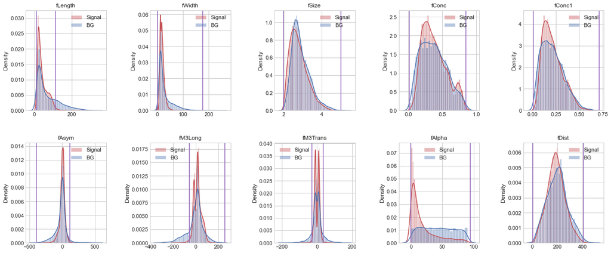

```python
fig, ax = plt.subplots(2,5, figsize=(18, 8))
ax = ax.flatten()
for i in range(10):
    sns.distplot(datasets['g'].iloc[:,i].values, ax=ax[i],color='r', label='Signal')
    sns.distplot(datasets['h'].iloc[:,i].values, ax=ax[i],color='b', label='BG')
    cor=cortes1[i]
    ax[i].axvline( x=cor[0], ymin=0, ymax=1,c='tab:purple')
    ax[i].axvline( x=cor[1], ymin=0, ymax=1,c='tab:purple')
    ax[i].set_title(datasets['g'].columns[i])
    ax[i].legend(loc="best")
fig.tight_layout(pad=2.0)
```

```python
rf_model_c1  = RandomForestClassifier(criterion='entropy',random_state = 0,
                                bootstrap=RFC_params["bootstrap"],
                                max_depth=RFC_params["max_depth"],
                                max_features=RFC_params["max_features"],
                                n_estimators=RFC_params["n_estimators"],
                                );
scores1=[]
porcsignal1=[]
porbackground1=[]
portot1=[]
#Score of the Random Forest Classifier model :
for i in range(10):
    datasetc1 = {}
    Xcut1=cortes1[i]
    name=df.columns[i]
    dfcut1=df[(df[name] >Xcut1[0]) & (df[name] <Xcut1[1])].dropna()
    by_classc = dfcut1.groupby('class')

    for groups, data in by_classc:
          datasetc1[groups] = data.drop(columns=['class'])
    porcsignal1.append(len(datasetc1['g'])/signn)
    porbackground1.append(len(datasetc1['h'])/backn)
    portot1.append(len(dfcut1)/len(df))

    # Create target object and call it y
    ycut1 = dfcut1['class'].replace('g',1).replace('h',0)

    # Create X
    features1 = list(dfcut1)[:-1]
    Xcut1 = dfcut1[features1]
    score=cross_val_score(rf_model_c1, Xcut1, ycut1, scoring='accuracy')
    scores1.append(score)
    #print(name+' cut')
    #print(score)
    #print()
```

```python
cutall1= cross_val_score(rf_model_c1, Xcutall1, ycutall1, scoring='accuracy')
```

```python
cut_1=[]
for i in range(10):
  cut_1.append([df.columns[i],porcsignal1[i],porbackground1[i],portot1[i],scores1[i].mean(),significan1[i],significan1[i]/(signn/backn**0.5)])

cut_1.append(["All",signcutall1/signn,backcutall1/backn,(backcutall1+signcutall1)/len(df),cutall1.mean(),(-1*backcutall1+2*signcutall1),(-1*backcutall1+2*signcutall1)/(2*signn-backn)])

print(tabulate(cut_1, headers=title,numalign="right",floatfmt="1.3e",tablefmt="github"))
```

```
| Parameter   |    Signal |   Background |     Total |   Mean Accuracy RFC w GSCV estimators |   Significance |   Relative significance |
|-------------|-----------|--------------|-----------|---------------------------------------|----------------|-------------------------|
| fLength     | 9.895e-01 |    7.760e-01 | 9.144e-01 |                             8.755e-01 |      1.694e+02 |               1.123e+00 |
| fWidth      | 1.000e+00 |    9.985e-01 | 9.995e-01 |                             8.817e-01 |      1.509e+02 |               1.001e+00 |
| fSize       | 1.000e+00 |    9.993e-01 | 9.997e-01 |                             8.805e-01 |      1.509e+02 |               1.000e+00 |
| fConc       | 9.996e-01 |    9.958e-01 | 9.983e-01 |                             8.818e-01 |      1.510e+02 |               1.002e+00 |
| fConc1      | 9.999e-01 |    9.981e-01 | 9.993e-01 |                             8.816e-01 |      1.509e+02 |               1.001e+00 |
| fAsym       | 9.981e-01 |    9.752e-01 | 9.901e-01 |                             8.814e-01 |      1.524e+02 |               1.011e+00 |
| fM3Long     | 9.886e-01 |    8.225e-01 | 9.302e-01 |                             8.772e-01 |      1.644e+02 |               1.090e+00 |
| fM3Trans    | 9.849e-01 |    8.032e-01 | 9.210e-01 |                             8.774e-01 |      1.657e+02 |               1.099e+00 |
| fAlpha      | 1.000e+00 |    1.000e+00 | 1.000e+00 |                             8.811e-01 |      1.508e+02 |               1.000e+00 |
| fDist       | 9.993e-01 |    9.925e-01 | 9.969e-01 |                             8.798e-01 |      1.513e+02 |               1.003e+00 |
| All         | 9.662e-01 |    6.743e-01 | 8.636e-01 |                             8.746e-01 |      1.932e+04 |               1.075e+00 |
```

| Parameter | Signal | Background | Total | Mean Accuracy RFC w GSCV estimators | Significance | Relative significance |
| --- | --- | --- | --- | --- | --- | --- |
| fLength | 9.895e-01 | 7.760e-01 | 9.144e-01 | 8.755e-01 | 1.694e+02 | 1.123e+00 |
| fWidth | 1.000e+00 | 9.985e-01 | 9.995e-01 | 8.817e-01 | 1.509e+02 | 1.001e+00 |
| fSize | 1.000e+00 | 9.993e-01 | 9.997e-01 | 8.805e-01 | 1.509e+02 | 1.000e+00 |
| fConc | 9.996e-01 | 9.958e-01 | 9.983e-01 | 8.818e-01 | 1.510e+02 | 1.002e+00 |
| fConc1 | 9.999e-01 | 9.981e-01 | 9.993e-01 | 8.816e-01 | 1.509e+02 | 1.001e+00 |
| fAsym | 9.981e-01 | 9.752e-01 | 9.901e-01 | 8.814e-01 | 1.524e+02 | 1.011e+00 |
| fM3Long | 9.886e-01 | 8.225e-01 | 9.302e-01 | 8.772e-01 | 1.644e+02 | 1.090e+00 |
| fM3Trans | 9.849e-01 | 8.032e-01 | 9.210e-01 | 8.774e-01 | 1.657e+02 | 1.099e+00 |
| fAlpha | 1.000e+00 | 1.000e+00 | 1.000e+00 | 8.811e-01 | 1.508e+02 | 1.000e+00 |
| fDist | 9.993e-01 | 9.925e-01 | 9.969e-01 | 8.798e-01 | 1.513e+02 | 1.003e+00 |
| All | 9.662e-01 | 6.743e-01 | 8.636e-01 | 8.746e-01 | 1.932e+04 | 1.075e+00 |

## Minimization function: Significance

Obteniendo los cortes a partir de reducción (optimización) de la función [(#signal)/(#background)^0.5]^-1

```python
def cut2(x,i):
    #señal
    j = datasets['g'].iloc[:,i].values
    gg=len([1 for o in j if x[0] < o < x[1] ])
    if gg==0:
      gg=2.220446049250313e-16
    #fondo
    j = datasets['h'].iloc[:,i].values
    hh=len([1 for o in j if x[0] < o < x[1]])
    return (hh**0.5)/gg
```

### CG method

```python
cortes2=[]
significan2=[]
for i in range(10):
  x0 = np.array([min(datasets['g'].iloc[:,i].values), max(datasets['g'].iloc[:,i].values)])
  print(str(df.columns[i]))
  res2 = minimize(cut2, x0,args=(i), method='CG',#'nelder-mead',
                  options={ 'disp': True})#'xatol': 1e-8,...,bounds=(min(datasets['g'].iloc[:,i].values), max(datasets['h'].iloc[:,i].values)))
  limits=res2.x
  significan2.append(cut2(limits,i))
  print(limits)
  cortes2.append(limits)
  print()
```

```
fLength
Optimization terminated successfully.
         Current function value: 0.006591
         Iterations: 1
         Function evaluations: 33
         Gradient evaluations: 11
[ 12.1929     272.06305126]

fWidth
Optimization terminated successfully.
         Current function value: 0.006659
         Iterations: 1
         Function evaluations: 33
         Gradient evaluations: 11
[  0.         176.33505126]

fSize
Optimization terminated successfully.
         Current function value: 0.006629
         Iterations: 1
         Function evaluations: 33
         Gradient evaluations: 11
[1.9978     5.01005127]

fConc
Optimization terminated successfully.
         Current function value: 0.006629
         Iterations: 1
         Function evaluations: 33
         Gradient evaluations: 11
[0.0139    0.8889513]

fConc1
Optimization terminated successfully.
         Current function value: 0.006628
         Iterations: 1
         Function evaluations: 33
         Gradient evaluations: 11
[0.0073     0.67525126]

```

[output cut: 24 more lines]

```
fAlpha
Optimization terminated successfully.
         Current function value: 0.006634
         Iterations: 1
         Function evaluations: 33
         Gradient evaluations: 11
[ 0.         90.00005126]

fDist
Optimization terminated successfully.
         Current function value: 0.006629
         Iterations: 1
         Function evaluations: 33
         Gradient evaluations: 11
[  5.7456     450.40205126]
```

#### Combination of all cuts

Cutting the dataset:

```python
dfcutall2=df
sizw=[len(dfcutall2)]
for i in range(10):
  Xcut=cortes2[i]
  name=dfcutall2.columns[i]
  dfcutall2=dfcutall2[(dfcutall2[name] >Xcut[0]) & (dfcutall2[name] <Xcut[1])].dropna()
  sizw.append(len(dfcutall2))
#sizw
```

Once the data is cutted, lets split the data in signal v background:

```python
datasetcutall2 = {}
by_class = dfcutall2.groupby('class')

for groups, data in by_class:
    datasetcutall2[groups] = data.drop(columns=['class'])

#number of events that are signal:
signcutall2=len(datasetcutall2['g'])
# number of events that are background:
backcutall2=len(datasetcutall2['h'])
```

Dividing the data in X and y:

```python
# Create target object and call it y
ycutall2 = dfcutall2['class'].replace('g',1).replace('h',0)

# Create X
features = list(dfcutall2)[:-1]
Xcutall2 = dfcutall2[features]
```

Plots of distributions

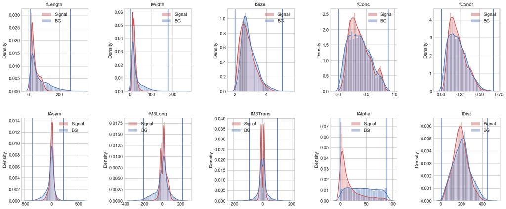

```python
fig, ax = plt.subplots(2,5, figsize=(18, 8))
ax = ax.flatten()
for i in range(10):
    sns.distplot(datasets['g'].iloc[:,i].values, ax=ax[i],color='r', label='Signal')
    sns.distplot(datasets['h'].iloc[:,i].values, ax=ax[i],color='b', label='BG')
    cor2=cortes2[i]
    ax[i].axvline( x=cor2[0], ymin=0, ymax=1)
    ax[i].axvline( x=cor2[1], ymin=0, ymax=1)
    ax[i].set_title(datasets['g'].columns[i])
    ax[i].legend(loc="best")
fig.tight_layout(pad=2.0)
```

```python
rf_model_c2  = RandomForestClassifier(criterion = 'entropy', random_state = 0)
scores2=[]
porcsignal2=[]
porbackground2=[]
portot2=[]
#Score of the Random Forest Classifier model :
for i in range(10):
    datasetc2 = {}
    Xcut2=cortes2[i]
    name=df.columns[i]
    dfcut2=df[(df[name] >Xcut2[0]) & (df[name] <Xcut2[1])].dropna()
    by_classc2 = dfcut2.groupby('class')

    for groups, data in by_classc2:
          datasetc2[groups] = data.drop(columns=['class'])

    porcsignal2.append(len(datasetc2['g'])/signn)
    porbackground2.append(len(datasetc2['h'])/backn)
    portot2.append(len(dfcut2)/len(df))

    # Create target object and call it y
    ycut2 = dfcut2['class'].replace('g',1).replace('h',0)

    # Create X
    features2 = list(dfcut2)[:-1]
    Xcut2 = dfcut2[features2]
    score2=cross_val_score(rf_model_c2, Xcut2, ycut2, scoring='accuracy')
    scores2.append(score2)
#    print(name+' cut')
#    print(score2)
#    print()
```

```python
cutall2= cross_val_score(rf_model_c2, Xcutall2, ycutall2, scoring='accuracy')
```

```python
cut_2=[]
for i in range(10):
  cut_2.append([df.columns[i],porcsignal2[i],porbackground2[i],portot2[i],scores2[i].mean(),significan2[i]**-1,(significan2[i]**-1)/(signn/backn**0.5)])

cut_2.append(["All",signcutall2/signn,backcutall2/backn,(backcutall2+signcutall2)/len(df),cutall2.mean(),(signcutall2/backcutall2**0.5),(signcutall2/backcutall2**0.5)/(signn/backn**0.5)])

print(tabulate(cut_2, headers=title,numalign="right",floatfmt="1.3e",tablefmt="github"))
```

```
| Parameter   |    Signal |   Background |     Total |   Mean Accuracy RFC w GSCV estimators |   Significance |   Relative significance |
|-------------|-----------|--------------|-----------|---------------------------------------|----------------|-------------------------|
| fLength     | 9.999e-01 |    9.876e-01 | 9.956e-01 |                             8.796e-01 |      1.517e+02 |               1.006e+00 |
| fWidth      | 9.937e-01 |    9.955e-01 | 9.943e-01 |                             8.820e-01 |      1.502e+02 |               9.959e-01 |
| fSize       | 9.999e-01 |    9.990e-01 | 9.996e-01 |                             8.809e-01 |      1.509e+02 |               1.000e+00 |
| fConc       | 9.999e-01 |    9.991e-01 | 9.996e-01 |                             8.805e-01 |      1.508e+02 |               1.000e+00 |
| fConc1      | 9.999e-01 |    9.988e-01 | 9.995e-01 |                             8.803e-01 |      1.509e+02 |               1.001e+00 |
| fAsym       | 9.999e-01 |    9.919e-01 | 9.971e-01 |                             8.810e-01 |      1.514e+02 |               1.004e+00 |
| fM3Long     | 9.999e-01 |    9.855e-01 | 9.948e-01 |                             8.798e-01 |      1.519e+02 |               1.007e+00 |
| fM3Trans    | 9.999e-01 |    9.833e-01 | 9.941e-01 |                             8.795e-01 |      1.521e+02 |               1.008e+00 |
| fAlpha      | 9.996e-01 |    1.000e+00 | 9.997e-01 |                             8.805e-01 |      1.507e+02 |               9.996e-01 |
| fDist       | 9.999e-01 |    9.990e-01 | 9.996e-01 |                             8.811e-01 |      1.509e+02 |               1.000e+00 |
| All         | 9.929e-01 |    9.499e-01 | 9.778e-01 |                             8.800e-01 |      1.536e+02 |               1.019e+00 |
```

| Parameter | Signal | Background | Total | Mean Accuracy RFC w GSCV estimators | Significance | Relative significance |
| --- | --- | --- | --- | --- | --- | --- |
| fLength | 9.999e-01 | 9.876e-01 | 9.956e-01 | 8.796e-01 | 1.517e+02 | 1.006e+00 |
| fWidth | 9.937e-01 | 9.955e-01 | 9.943e-01 | 8.820e-01 | 1.502e+02 | 9.959e-01 |
| fSize | 9.999e-01 | 9.990e-01 | 9.996e-01 | 8.809e-01 | 1.509e+02 | 1.000e+00 |
| fConc | 9.999e-01 | 9.991e-01 | 9.996e-01 | 8.805e-01 | 1.508e+02 | 1.000e+00 |
| fConc1 | 9.999e-01 | 9.988e-01 | 9.995e-01 | 8.803e-01 | 1.509e+02 | 1.001e+00 |
| fAsym | 9.999e-01 | 9.919e-01 | 9.971e-01 | 8.810e-01 | 1.514e+02 | 1.004e+00 |
| fM3Long | 9.999e-01 | 9.855e-01 | 9.948e-01 | 8.798e-01 | 1.519e+02 | 1.007e+00 |
| fM3Trans | 9.999e-01 | 9.833e-01 | 9.941e-01 | 8.795e-01 | 1.521e+02 | 1.008e+00 |
| fAlpha | 9.996e-01 | 1.000e+00 | 9.997e-01 | 8.805e-01 | 1.507e+02 | 9.996e-01 |
| fDist | 9.999e-01 | 9.990e-01 | 9.996e-01 | 8.811e-01 | 1.509e+02 | 1.000e+00 |
| All | 9.929e-01 | 9.499e-01 | 9.778e-01 | 8.800e-01 | 1.536e+02 | 1.019e+00 |

### Nelder-mead method

```python
cortes3=[]
signifan3=[]
for i in range(10):
  x0 = np.array([min(datasets['g'].iloc[:,i].values), max(datasets['g'].iloc[:,i].values)])
  print(str(df.columns[i]))
  res3 = minimize(cut2, x0,args=(i), method='nelder-mead',
                  options={ 'xatol': 1e-8,'disp': True})#'xatol': 1e-8,...,bounds=(min(datasets['g'].iloc[:,i].values), max(datasets['h'].iloc[:,i].values)))
  limits3=res3.x
  signifan3.append(cut2(limits3,i))
  print(limits3)
  cortes3.append(limits3)
  print()
cortes3=np.array(cortes3)
```

```
fLength
Optimization terminated successfully.
         Current function value: 0.000000
         Iterations: 45
         Function evaluations: 154
[12.55487672  5.31373047]

fWidth
Optimization terminated successfully.
         Current function value: 0.005960
         Iterations: 50
         Function evaluations: 144
[-1.13352966e-03  3.96769894e+01]

fSize
Optimization terminated successfully.
         Current function value: 0.006609
         Iterations: 44
         Function evaluations: 123
[1.99350814 4.31813057]

fConc
Optimization terminated successfully.
         Current function value: 0.006621
         Iterations: 30
         Function evaluations: 93
[0.01443754 0.83126039]

fConc1
Optimization terminated successfully.
         Current function value: 0.006527
         Iterations: 48
         Function evaluations: 129
[0.06326423 0.96240727]

fAsym
Optimization terminated successfully.
         Current function value: 0.006559
         Iterations: 45
         Function evaluations: 151
```

[output cut: 14 more lines]

```
[-27.37154417  26.42620607]

fAlpha
Optimization terminated successfully.
         Current function value: 0.006632
         Iterations: 33
         Function evaluations: 124
[-2.50e-04  9.45e+01]

fDist
Optimization terminated successfully.
         Current function value: 0.006589
         Iterations: 40
         Function evaluations: 133
[  6.59060719 360.14566172]
```

#### Combination of all cuts

```python
dfcutall3=df
sizw=[len(dfcutall3)]
for i in range(1,10):
  Xcut3=cortes3[i]
  name=dfcutall3.columns[i]
  dfcutall3=dfcutall3[(dfcutall3[name] >Xcut3[0]) & (dfcutall3[name] <Xcut3[1])].dropna()
  sizw.append(len(dfcutall3))
#sizw
```

```python
datasetcutall3 = {}
by_class = dfcutall3.groupby('class')

for groups, data in by_class:
    datasetcutall3[groups] = data.drop(columns=['class'])

signcutall3=len(datasetcutall3['g'])
backcutall3=len(datasetcutall3['h'])
significancetotal3=signcutall3/backcutall3**0.5
```

```python
# Create target object and call it y
ycutall3 = dfcutall3['class'].replace('g',1).replace('h',0)

# Create X
features = list(dfcutall3)[:-1]
Xcutall3 = dfcutall3[features]
```

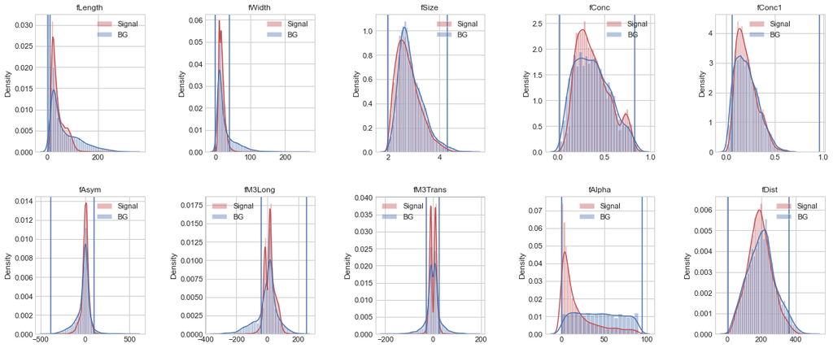

```python
fig, ax = plt.subplots(2,5, figsize=(18, 8))
ax = ax.flatten()
for i in range(10):
    sns.distplot(datasets['g'].iloc[:,i].values, ax=ax[i],color='r', label='Signal')
    sns.distplot(datasets['h'].iloc[:,i].values, ax=ax[i],color='b', label='BG')
    cor3=cortes3[i]
    ax[i].axvline( x=cor3[0], ymin=0, ymax=1)
    ax[i].axvline( x=cor3[1], ymin=0, ymax=1)
    ax[i].set_title(datasets['g'].columns[i])
    ax[i].legend(loc="best")
fig.tight_layout(pad=2.0)
```

```python
rf_model_c3  = RandomForestClassifier(criterion = 'entropy', random_state = 0)
scores3=[]
porcsignal3=[]
porbackground3=[]
portot3=[]
#Score of the Random Forest Classifier model :
for i in range(1,10):
    datasetc3 = {}
    Xcut3=cortes3[i]
    name=df.columns[i]
    dfcut3=df[(df[name] >Xcut3[0]) & (df[name] <Xcut3[1])].dropna()
    by_classc3 = dfcut3.groupby('class')

    for groups, data in by_classc3:
          datasetc3[groups] = data.drop(columns=['class'])

    porcsignal3.append(len(datasetc3['g'])/signn)
    porbackground3.append(len(datasetc3['h'])/backn)
    portot3.append(len(dfcut3)/len(df))

    # Create target object and call it y
    ycut3 = dfcut3['class'].replace('g',1).replace('h',0)

    # Create X
    features3 = list(dfcut3)[:-1]
    Xcut3 = dfcut3[features3]
    score3=cross_val_score(rf_model_c3, Xcut3, ycut3, scoring='accuracy')
    scores3.append(score3)
    #print(name+' cut')
    #print(score3)
    #print()
```

```python
cutall3= cross_val_score(rf_model_c3, Xcutall3, ycutall3, scoring='accuracy')
```

```python
cut_3=[]
for i in range(1,10):
  cut_3.append([df.columns[i],porcsignal3[i-1],porbackground3[i-1],portot3[i-1],scores3[i-1].mean(),signifan3[i]**-1,(signifan3[i]**-1)/(signn/backn**0.5)])

cut_3.append(["All",signcutall3/signn,backcutall3/backn,(backcutall3+signcutall3)/len(df),cutall3.mean(),significancetotal3,significancetotal3/(signn/backn**0.5)])

print(tabulate(cut_3, headers=title,numalign="right",floatfmt="1.3e",tablefmt="github"))
```

```
| Parameter   |    Signal |   Background |     Total |   Mean Accuracy RFC w GSCV estimators |   Significance |   Relative significance |
|-------------|-----------|--------------|-----------|---------------------------------------|----------------|-------------------------|
| fWidth      | 9.766e-01 |    7.703e-01 | 9.040e-01 |                             8.742e-01 |      1.678e+02 |               1.113e+00 |
| fSize       | 9.972e-01 |    9.874e-01 | 9.937e-01 |                             8.802e-01 |      1.513e+02 |               1.003e+00 |
| fConc       | 9.981e-01 |    9.930e-01 | 9.963e-01 |                             8.807e-01 |      1.510e+02 |               1.002e+00 |
| fConc1      | 9.755e-01 |    9.218e-01 | 9.566e-01 |                             8.771e-01 |      1.532e+02 |               1.016e+00 |
| fAsym       | 9.959e-01 |    9.704e-01 | 9.870e-01 |                             8.812e-01 |      1.525e+02 |               1.011e+00 |
| fM3Long     | 9.720e-01 |    7.817e-01 | 9.051e-01 |                             8.759e-01 |      1.658e+02 |               1.099e+00 |
| fM3Trans    | 9.721e-01 |    7.727e-01 | 9.020e-01 |                             8.756e-01 |      1.668e+02 |               1.106e+00 |
| fAlpha      | 1.000e+00 |    1.000e+00 | 1.000e+00 |                             8.809e-01 |      1.508e+02 |               1.000e+00 |
| fDist       | 9.891e-01 |    9.656e-01 | 9.808e-01 |                             8.793e-01 |      1.518e+02 |               1.007e+00 |
| All         | 9.202e-01 |    6.471e-01 | 8.242e-01 |                             8.747e-01 |      1.725e+02 |               1.144e+00 |
```

| Parameter | Signal | Background | Total | Mean Accuracy RFC w GSCV estimators | Significance | Relative significance |
| --- | --- | --- | --- | --- | --- | --- |
| fWidth | 9.766e-01 | 7.703e-01 | 9.040e-01 | 8.742e-01 | 1.678e+02 | 1.113e+00 |
| fSize | 9.972e-01 | 9.874e-01 | 9.937e-01 | 8.802e-01 | 1.513e+02 | 1.003e+00 |
| fConc | 9.981e-01 | 9.930e-01 | 9.963e-01 | 8.807e-01 | 1.510e+02 | 1.002e+00 |
| fConc1 | 9.755e-01 | 9.218e-01 | 9.566e-01 | 8.771e-01 | 1.532e+02 | 1.016e+00 |
| fAsym | 9.959e-01 | 9.704e-01 | 9.870e-01 | 8.812e-01 | 1.525e+02 | 1.011e+00 |
| fM3Long | 9.720e-01 | 7.817e-01 | 9.051e-01 | 8.759e-01 | 1.658e+02 | 1.099e+00 |
| fM3Trans | 9.721e-01 | 7.727e-01 | 9.020e-01 | 8.756e-01 | 1.668e+02 | 1.106e+00 |
| fAlpha | 1.000e+00 | 1.000e+00 | 1.000e+00 | 8.809e-01 | 1.508e+02 | 1.000e+00 |
| fDist | 9.891e-01 | 9.656e-01 | 9.808e-01 | 8.793e-01 | 1.518e+02 | 1.007e+00 |
| All | 9.202e-01 | 6.471e-01 | 8.242e-01 | 8.747e-01 | 1.725e+02 | 1.144e+00 |

# Removing highly correlated parameters

Deleting the parameter 'fConc1' because it is verry correlated (p=0.98) with 'fConc1' and it can be redundant

```python
dfwofconc1 = df
del dfwofconc1['fConc1']
dfwofconc1.info()
```

```
<class 'pandas.core.frame.DataFrame'>
RangeIndex: 19020 entries, 0 to 19019
Data columns (total 10 columns):
 #   Column    Non-Null Count  Dtype
---  ------    --------------  -----
 0   fLength   19020 non-null  float64
 1   fWidth    19020 non-null  float64
 2   fSize     19020 non-null  float64
 3   fConc     19020 non-null  float64
 4   fAsym     19020 non-null  float64
 5   fM3Long   19020 non-null  float64
 6   fM3Trans  19020 non-null  float64
 7   fAlpha    19020 non-null  float64
 8   fDist     19020 non-null  float64
 9   class     19020 non-null  object
dtypes: float64(9), object(1)
memory usage: 1.5+ MB
```

Splitting X and y

```python
# Create target object and call it y
ywc = dfwofconc1['class'].replace('g',1).replace('h',0)

# Create X
features = list(dfwofconc1)[:-1]
Xwc = dfwofconc1[features]
```

Using a Random Forest Classifier with defined parameters gscv

```python
# Define the model. Set random_state to 0
rf_model_wc  =RandomForestClassifier(criterion='entropy',random_state = 0,
                                bootstrap=RFC_params["bootstrap"],
                                max_depth=RFC_params["max_depth"],
                                max_features=RFC_params["max_features"],
                                n_estimators=RFC_params["n_estimators"],
                                );
```

Cross Validation

```python
scorewc  =cross_val_score(rf_model_wc, Xwc, ywc, cv=5, scoring='accuracy')# in 5 groups
print('Mean Accuracy Score RFC w parameters: %2f' %(scorewc.mean()))
```

```
Mean Accuracy Score RFC w parameters: 0.881861
```

Spliting data in test and validation:

```python
# Split into validation and training data
train_X_wc, val_X_wc, train_y_wc, val_y_wc = train_test_split(Xwc, ywc, test_size = 0.25, random_state = 0)
```

Score

```python
# fit your model
rf_model_wc.fit(train_X_wc, train_y_wc)

print_score(rf_model_wc,train_X_wc, train_y_wc, val_X_wc, val_y_wc, train=False)
```

```
Test Result:
===========================================
accuracy score: 0.8841219768664563

Classification Report:
 	Precision: 0.8816425120772947
	Recall Score: 0.9483598570964599
	F1 score: 0.9137850101705524

Confusion Matrix:

+----------+---------------+---------------+
|          |   Predicted F |   Predicted T |
|----------+---------------+---------------|
| True F   |          1284 |           392 |
| True T   |           159 |          2920 |
+----------+---------------+---------------+

Relative Confusion Matrix:

+----------+---------------+---------------+
|          |   Predicted F |   Predicted T |
|----------+---------------+---------------|
| True F   |        0.766  |         0.234 |
| True T   |        0.0516 |         0.948 |
+----------+---------------+---------------+
```